# linear regression, Best Subset Model Selection

Arash Hatamirad, ahatamirad@gmail.com

9/1/2021

## Best Subset Model Selection

We will use heart.csv dataset. Below is brief summary of variables in heart.csv.

- Weight: subject’s weight
- Systolic: top number in a blood pressure reading, indicating the blood pressure level when the heart contracts
- Diastolic: bottom number in a blood pressure reading, indicating the blood pressure level when the heart is at rest or between beats
- Cholesterol: measured cholesterol

The data set contains Weight, Diastolic Blood pressure, Systolic blood pressure and Cholesterol for alive subjects in the heart.csv.

```r
# Read the CSV file
d1 <- read.csv("heart.csv")

# Check data format
#str(d1)
```

consider the best subset selection for the Cholesterol model. Again, which has cook’s distance larger than 0.015, before performing the model selection.

- Find the best model based on adjusted-R square criteria and specify which predictors are selected.

#### Answer -:

##### Step 1) Run linear regressions with multicollinearity issue

```r
e2.lr <- lm( Cholesterol ~ Diastolic+Systolic+Weight  , data=d1)
summary(e2.lr)
```

```
##
## Call:
## lm(formula = Cholesterol ~ Diastolic + Systolic + Weight, data = d1)
##
## Residuals:
##     Min      1Q  Median      3Q     Max
## -110.27  -29.58   -4.56   23.66  329.74
##
## Coefficients:
##              Estimate Std. Error t value Pr(>|t|)
## (Intercept) 157.88394    6.37201  24.778  < 2e-16 ***
## Diastolic     0.25983    0.10838   2.397   0.0166 *
## Systolic      0.30106    0.06443   4.672  3.1e-06 ***
## Weight        0.02146    0.02903   0.739   0.4597
## ---
## Signif. codes:  0 '***' 0.001 '**' 0.01 '*' 0.05 '.' 0.1 ' ' 1
##
## Residual standard error: 42.95 on 3130 degrees of freedom
## Multiple R-squared:  0.03606,    Adjusted R-squared:  0.03513
## F-statistic: 39.03 on 3 and 3130 DF,  p-value: < 2.2e-16
```

##### Result:

- P-Value of F-Test is significant. Thus, the model is useful.

In the other word, there exist linear regression for cholesterol as a function of diastolic, systolic, and weight.

##### Step 2) Perform Correlation to find Multicollinearity

- Two methods:

  ```
      - 1) Pairwise Scatter Plot

      - 2) Quantitative Method (VIF's)
  ```

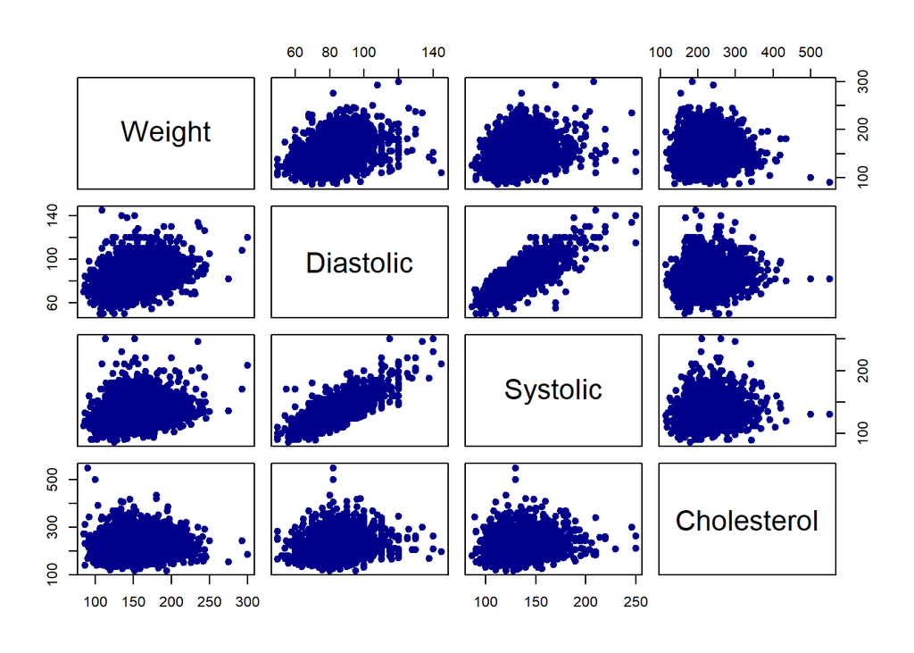

```r
pairs(d1,pch=19, col="darkblue")
```

##### Result:

```r
vif(e2.lr)
```

```
## Diastolic  Systolic    Weight
##  2.558682  2.454214  1.120375
```

##### Step 3) Perform Diagnostic Plot

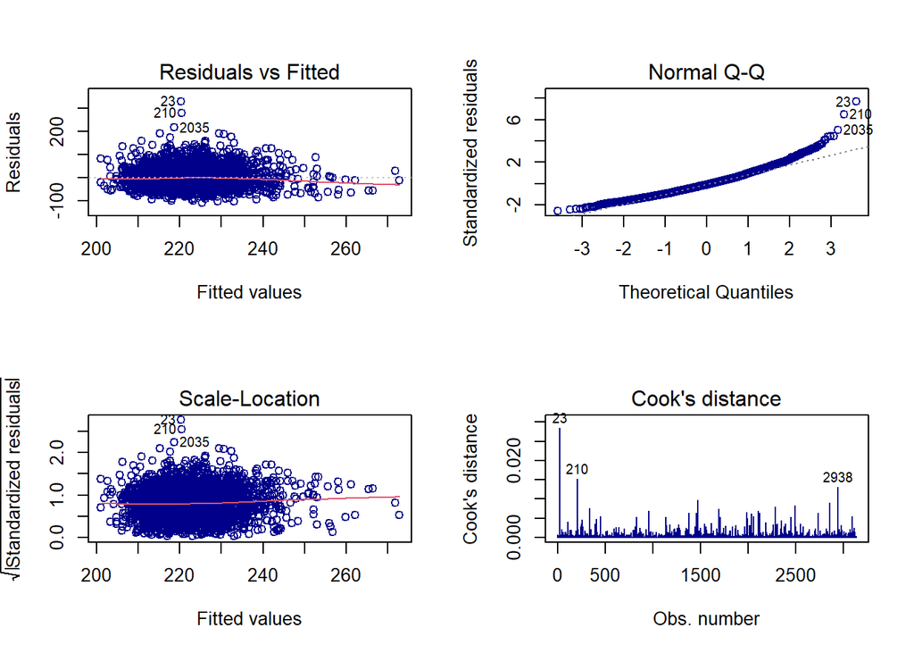

```r
par(mfrow=c(2,2))
plot(e2.lr,which=1:4,col="darkblue")
```

##### Step 4) Influential points

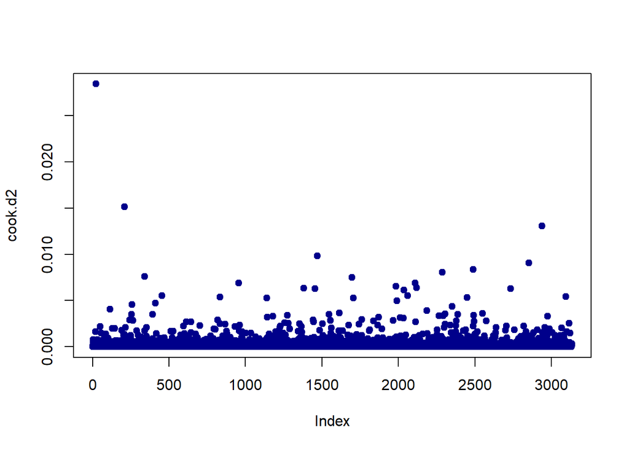

```r
cook.d2 <- cooks.distance(e2.lr)
plot(cook.d2,col="darkblue",pch=19,cex=1)
```

- Delete observations larger than criteria (0.015)

```r
e2.inf.id <- which(cooks.distance(e2.lr)>0.015)
e2.lr2 <- lm(Cholesterol ~ Diastolic+Systolic+Weight  , data=d1[-e2.inf.id,])
summary(e2.lr2)
```

```
##
## Call:
## lm(formula = Cholesterol ~ Diastolic + Systolic + Weight, data = d1[-e2.inf.id,
##     ])
##
## Residuals:
##      Min       1Q   Median       3Q      Max
## -110.617  -29.371   -4.476   23.755  216.041
##
## Coefficients:
##              Estimate Std. Error t value Pr(>|t|)
## (Intercept) 156.32618    6.27153  24.926  < 2e-16 ***
## Diastolic     0.24922    0.10665   2.337   0.0195 *
## Systolic      0.30073    0.06340   4.743  2.2e-06 ***
## Weight        0.03671    0.02860   1.284   0.1994
## ---
## Signif. codes:  0 '***' 0.001 '**' 0.01 '*' 0.05 '.' 0.1 ' ' 1
##
## Residual standard error: 42.26 on 3128 degrees of freedom
## Multiple R-squared:  0.03767,    Adjusted R-squared:  0.03675
## F-statistic: 40.81 on 3 and 3128 DF,  p-value: < 2.2e-16
```

##### Linear regression model:

```
    ŷ = 156.32618 + 0.24922 * Diastolic + 0.30073 * Systolic + 0.03671 * Weight
```

##### R Square (R2) and Adj. R Square:

Calculate R2 and Adj.R2

```r
summary(e2.lr2)$r.squared
```

```
## [1] 0.03766896
```

```r
summary(e2.lr2)$adj.r.squared
```

```
## [1] 0.03674601
```

```
    R Square is very small, thus, "Goodness of fit" or "Predictive power" is very low.

    Adj. R Square is very small too.
```

##### Step 5) Plot scatter, with and without influential points

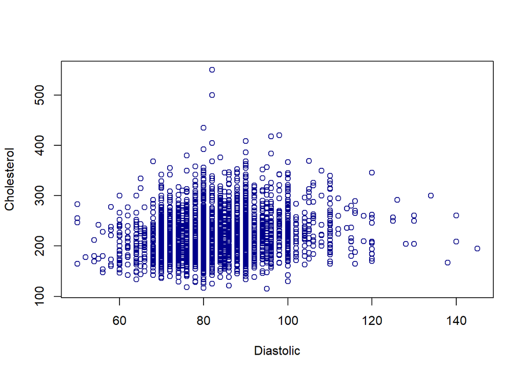

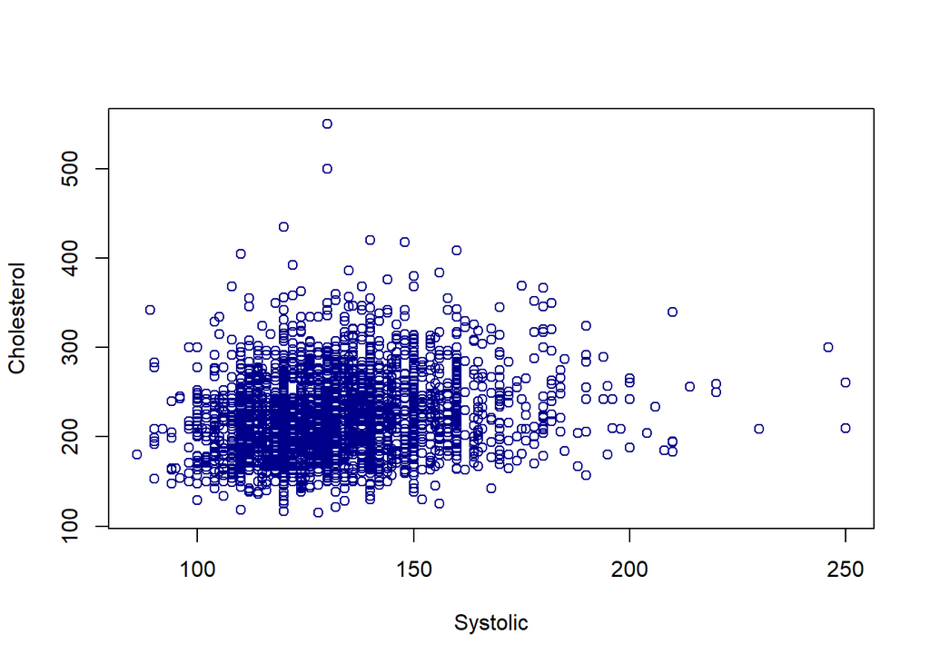

```r
with(d1,plot(Cholesterol ~ Diastolic+Systolic+Weight, col="darkblue"))
```

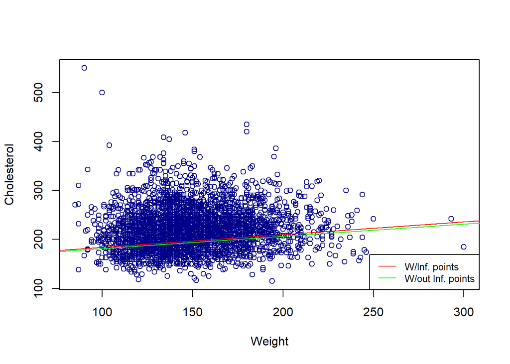

```r
abline(e2.lr,col="red")
abline(e2.lr2,col="green")
legend("bottomright",col=c("red","green"),legend = c("W/Inf. points","W/out Inf. points"),cex=0.8,title.adj = 0.15,lty=1)
```

##### Step 6) Diagnostic plot for without influential points

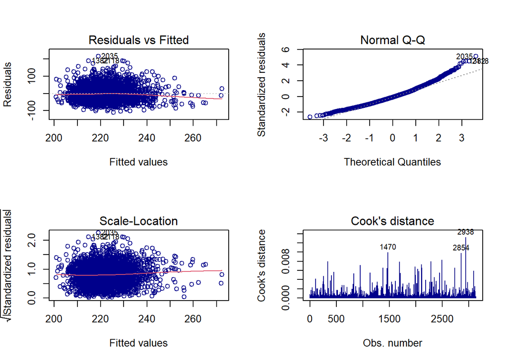

```r
par(mfrow=c(2,2))
plot(e2.lr2, which=c(1:4),col="darkblue")
```

#### Conclusion:

Regression lines with/without influential points are almost the same.

```r
e4.model.subset <- ols_step_best_subset(e2.lr2)
e4.model.subset
```

```
##         Best Subsets Regression
## ----------------------------------------
## Model Index    Predictors
## ----------------------------------------
##      1         Systolic
##      2         Diastolic Systolic
##      3         Diastolic Systolic Weight
## ----------------------------------------
##
##                                                           Subsets Regression Summary
## ----------------------------------------------------------------------------------------------------------------------------------------------
##                        Adj.        Pred
## Model    R-Square    R-Square    R-Square     C(p)        AIC           SBIC          SBC            MSEP           FPE        HSP       APC
## ----------------------------------------------------------------------------------------------------------------------------------------------
##   1        0.0350      0.0347      0.0337    8.6847    32349.7666    23461.5297    32367.9149    5604396.2122    1790.5412    0.5719    0.9662
##   2        0.0372      0.0365      0.0352    3.6475    32344.7321    23456.5056    32368.9298    5593610.3978    1787.6653    0.5710    0.9647
##   3        0.0377      0.0367      0.0351    4.0000    32345.0829    23456.8621    32375.3300    5592453.6261    1787.8655    0.5710    0.9648
## ----------------------------------------------------------------------------------------------------------------------------------------------
## AIC: Akaike Information Criteria
##  SBIC: Sawa's Bayesian Information Criteria
##  SBC: Schwarz Bayesian Criteria
##  MSEP: Estimated error of prediction, assuming multivariate normality
##  FPE: Final Prediction Error
##  HSP: Hocking's Sp
##  APC: Amemiya Prediction Criteria
```

For Adj. R Square, bigger is better, thus Adj. R-Square=0.0367 is related to Model #3, thus the best selected model is:  
Model #3: Diastolic Systolic Weight

```r
e4.lr.subset.a <- lm(Cholesterol ~ Diastolic+Systolic+Weight,  data=d1[-e2.inf.id,])
summary(e4.lr.subset.a)
```

```
##
## Call:
## lm(formula = Cholesterol ~ Diastolic + Systolic + Weight, data = d1[-e2.inf.id,
##     ])
##
## Residuals:
##      Min       1Q   Median       3Q      Max
## -110.617  -29.371   -4.476   23.755  216.041
##
## Coefficients:
##              Estimate Std. Error t value Pr(>|t|)
## (Intercept) 156.32618    6.27153  24.926  < 2e-16 ***
## Diastolic     0.24922    0.10665   2.337   0.0195 *
## Systolic      0.30073    0.06340   4.743  2.2e-06 ***
## Weight        0.03671    0.02860   1.284   0.1994
## ---
## Signif. codes:  0 '***' 0.001 '**' 0.01 '*' 0.05 '.' 0.1 ' ' 1
##
## Residual standard error: 42.26 on 3128 degrees of freedom
## Multiple R-squared:  0.03767,    Adjusted R-squared:  0.03675
## F-statistic: 40.81 on 3 and 3128 DF,  p-value: < 2.2e-16
```

```r
summary(e4.lr.subset.a)$r.squared
```

```
## [1] 0.03766896
```

```r
summary(e4.lr.subset.a)$adj.r.squared
```

```
## [1] 0.03674601
```

This is the value which is explained by model.

### Best Subset MOdel Selection by AIC

- Find the best model based on AIC criteria and specify which predictors are selected.

#### Answer -:

```r
e4.lr.subset.b <- lm(Cholesterol ~ Diastolic+Systolic, data=d1[-e2.inf.id,])
summary(e4.lr.subset.b)
```

```
##
## Call:
## lm(formula = Cholesterol ~ Diastolic + Systolic, data = d1[-e2.inf.id,
##     ])
##
## Residuals:
##      Min       1Q   Median       3Q      Max
## -109.332  -29.399   -4.433   23.922  217.241
##
## Coefficients:
##             Estimate Std. Error t value Pr(>|t|)
## (Intercept) 159.3317     5.8186  27.383  < 2e-16 ***
## Diastolic     0.2770     0.1044   2.652  0.00803 **
## Systolic      0.3022     0.0634   4.767 1.95e-06 ***
## ---
## Signif. codes:  0 '***' 0.001 '**' 0.01 '*' 0.05 '.' 0.1 ' ' 1
##
## Residual standard error: 42.26 on 3129 degrees of freedom
## Multiple R-squared:  0.03716,    Adjusted R-squared:  0.03655
## F-statistic: 60.38 on 2 and 3129 DF,  p-value: < 2.2e-16
```

The final Model - based on AIC in subset method - is:  
ŷ = 159.3317 + 0.2770 * Diastolic + 0.3022 * Systolic

```r
summary(e4.lr.subset.b)$r.squared
```

```
## [1] 0.0371621
```

```r
summary(e4.lr.subset.b)$adj.r.squared
```

```
## [1] 0.03654667
```

This is the value which is explained by model.

- Compare final models selected in a) and b). Also, compare final models from the best subset approach with the final model from the stepwise selection.

#### Answer -:

Subset Selection with Adj. R-Square result

- 1. Final model selected by Subset Selection with Adj. R-Squared criteria:  
     ŷ = 156.32618 + 0.2492 * Diastolic + 0.30073 * Systolic + 0.03671 * Weight  
     And prediction power is (R Square): 0.03767

Subset Selection with AIC result

- 2. Final model selected by Subset Selection with AIC criteria:  
     ŷ = 159.3317 + 0.2770 * Diastolic + 0.3022 * Systolic  
     And prediction power is (R Square): 0.03716

#### Conclusion:

  ```
    - Results (B) and (C), have less goodness of fit, but have model simplicity (only two predictors)
    - Result of (A) has more goodness of fit, but more complexity (three predictors) and includes an insignificant variable (Weight)
  ```

Since, Choosing the final model is dependent to our business, best fitting model is not always maximum fitting model, therefore if prediction is important for us, thus we must choose model B (or C, which is same).